# Homework 1

Kaylyn Zipp

February 7, 2021

1.Import the “beach.csv” dataset into R and examine the first few rows of data (5 points)

```r
beaches <- read.csv(file = 'beach.csv')
head(beaches)
```

```
##   BeachID Year OpenBeach
## 1       A 1992     437.8
## 2       A 1993     423.6
## 3       A 1994     333.1
## 4       A 1995     287.4
## 5       A 1996     295.6
## 6       A 1998     201.8
```

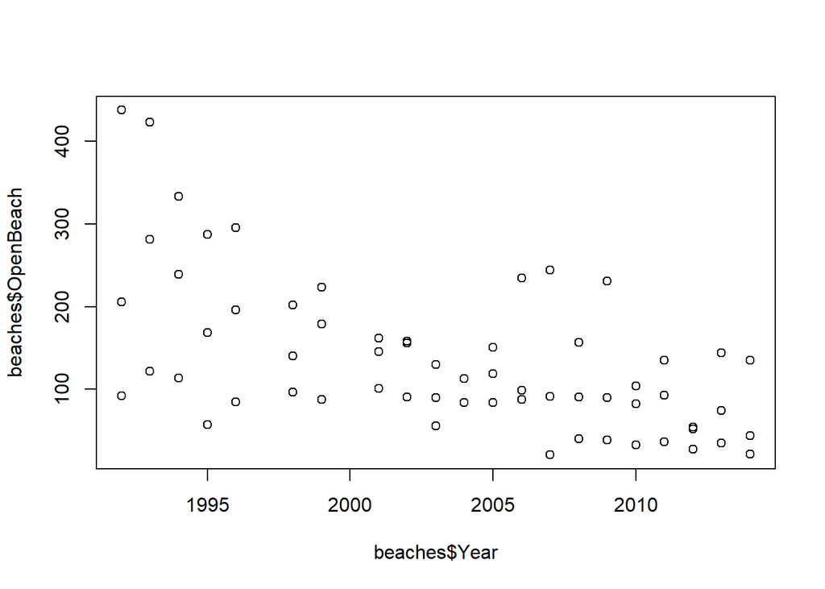

```r
plot(x=beaches$Year, y=beaches$OpenBeach)
```

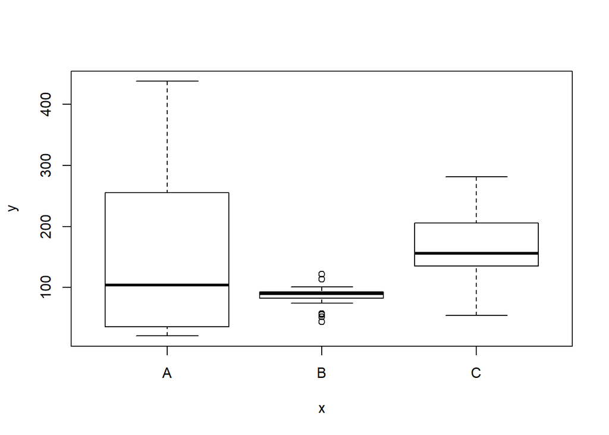

```r
plot(x=beaches$BeachID, y=beaches$OpenBeach)
```

2.Fit a model that includes interactions between Year and BeachID. Report estimates of all coefficients (5 points)

The annual change in open beach area created by BeachID

```r
fit <- lm(OpenBeach ~ Year * BeachID, data = beaches)
print(fit)
```

```
##
## Call:
## lm(formula = OpenBeach ~ Year * BeachID, data = beaches)
##
## Coefficients:
##   (Intercept)           Year       BeachIDB       BeachIDC  Year:BeachIDB
##      36945.73         -18.36      -34211.98      -28776.11          17.04
## Year:BeachIDC
##         14.37
```

Equation y = β0 + β1 × years + β2 × B + β3 × BeachID + β4 × years × BeachID + + β5 × years × BeachID

3. Predict the beach area at all three beaches in 1992 (5 points)

Area at Beach A

Beach A Dummy Coding = 0 Equation Breaks down to: y = β0 + β1 × years

36945.73 + -18.36 * 1992

```r
beachareaof_a_1992<-36945.73 + -18.36 * 1992
print(beachareaof_a_1992)
```

```
## [1] 372.61
```

Area at Beach B

Beach B Dummy Coding = 1 for BeachIDB but 0 for BeachIDC y = β0 + β1 × years + β2 × BeachIDB + β3 × BeachIDC + β4 × years × BeachIDB + β5 × years × BeachIDC

Simplified

y = β0 + β1 × years + β2 × 1 + β3 × 0 + β4 × years × 1 + β5 × years × 0

y = β0 + β1 × years + β2 × 1 + β4 × years × 1

36945.73 + -18.36 * years + -34211.98 + 17.04 * years

36945.73 + -18.36 * 1992 + -34211.98 + 17.04 * 1992

```r
beachareaof_b_1992<-36945.73 + -18.36 * 1992 + -34211.98 + 17.04 * 1992
print(beachareaof_b_1992)
```

```
## [1] 104.31
```

Area at Beach C

Beach C Dummy Coding = 0 for BeachIDB but 1 for BeachIDC y = β0 + β1 × years + β2 × BeachIDB + β3 × BeachIDC + β4 × years × BeachIDB + β5 × years × BeachIDC

Simplified y = β0 + β1 × years + β3 × BeachIDC + β5 × years × BeachIDC

y = β0 + β1 × years + β3 × 1 + β5 × years × 1

36945.73 + -18.36 * years + -28776.11 + 14.37 * years

36945.73 + -18.36 * 1992 + -28776.11 + 14.37 * 1992

```r
beachareaof_c_1992 <- 36945.73 + -18.36 * 1992 + -28776.11 + 14.37 * 1992
print(beachareaof_c_1992)
```

```
## [1] 221.54
```

4. Plot the predicted area of each beach across all years

[figure not shown]

```r
timespan<-seq(from = 1992, to = 2014, by = 1)
predictedbeachareaof_a<-36945.73 + -18.36 * timespan
predictedbeachareaof_b<-36945.73 + -18.36 * timespan + -34211.98 + 17.04 * timespan
predictedbeachareaof_c<-36945.73 + -18.36 * timespan + -28776.11 + 14.37 * timespan

plot(x = timespan, y = predictedbeachareaof_a, type = 'l', xlab = 'Years', ylab = 'Open Beach Area')
lines(x = timespan, y=predictedbeachareaof_b, col = 'blue')
lines(x = timespan, y = predictedbeachareaof_c, col = 'red')
legend('bottomleft', legend = c('Beach A', 'Beach B', 'Beach C'), col = c('red','blue','black'),pch = c('...'))
```

5. Interpret the rate of beach area change at each of the 3 beaches (5 points)

```r
BeachA <- lm(predictedbeachareaof_a ~ timespan)
print(BeachA)
```

```
##
## Call:
## lm(formula = predictedbeachareaof_a ~ timespan)
##
## Coefficients:
## (Intercept)     timespan
##    36945.73       -18.36
```

```r
BeachB <- lm(predictedbeachareaof_b ~ timespan)
print(BeachB)
```

```
##
## Call:
## lm(formula = predictedbeachareaof_b ~ timespan)
##
## Coefficients:
## (Intercept)     timespan
##     2733.75        -1.32
```

```r
BeachC <- lm(predictedbeachareaof_c ~ timespan)
print(BeachC)
```

```
##
## Call:
## lm(formula = predictedbeachareaof_c ~ timespan)
##
## Coefficients:
## (Intercept)     timespan
##     8169.62        -3.99
```

All three of the beaches, A, B & C, are declining in open area over time steadily. Beach A is decreasing at the fastest rate, -18.36 units per year. Beach c is decreasing by a rate of 3.99 units per year. Beach b is decreasing the slowest, at a rate of -1.32 units per year. Based on the information provided if management is interested in stemming the lost of potential nesting sites then beach A should be focused on.